# Risk Factor Analysis

## Outcome Variable

**Outcome Variable:** y_rate_len

## Predictor Variables

**Intervention Variable:** nrooms

**Adjustment Set:**

- arm
- sex
- W_mage
- meducyrs
- feducyrs
- hhwealth_quart
- hfoodsec
- W_mhtcm
- W_nchldlt5
- W_parity
- impfloor
- impsan
- safeh20
- delta_W_mage
- delta_meducyrs
- delta_feducyrs
- delta_hhwealth_quart
- delta_hfoodsec
- delta_W_mhtcm
- delta_W_nchldlt5
- delta_W_parity
- delta_impfloor
- delta_impsan
- delta_safeh20

## Stratifying Variables

The analysis was stratified on these variable(s):

- agecat
- studyid
- country

## Data Summary

| agecat | studyid | country | nrooms | n_cell | n |
| --- | --- | --- | --- | --- | --- |
| 0-3 months | ki0047075b-MAL-ED | BANGLADESH | 1 | 149 | 237 |
| 0-3 months | ki0047075b-MAL-ED | BANGLADESH | 2 | 49 | 237 |
| 0-3 months | ki0047075b-MAL-ED | BANGLADESH | 3 | 28 | 237 |
| 0-3 months | ki0047075b-MAL-ED | BANGLADESH | 4+ | 11 | 237 |
| 0-3 months | ki0047075b-MAL-ED | BRAZIL | 1 | 3 | 174 |
| 0-3 months | ki0047075b-MAL-ED | BRAZIL | 2 | 19 | 174 |
| 0-3 months | ki0047075b-MAL-ED | BRAZIL | 3 | 50 | 174 |
| 0-3 months | ki0047075b-MAL-ED | BRAZIL | 4+ | 102 | 174 |
| 0-3 months | ki0047075b-MAL-ED | INDIA | 1 | 73 | 194 |
| 0-3 months | ki0047075b-MAL-ED | INDIA | 2 | 68 | 194 |
| 0-3 months | ki0047075b-MAL-ED | INDIA | 3 | 31 | 194 |
| 0-3 months | ki0047075b-MAL-ED | INDIA | 4+ | 22 | 194 |
| 0-3 months | ki0047075b-MAL-ED | NEPAL | 1 | 37 | 174 |
| 0-3 months | ki0047075b-MAL-ED | NEPAL | 2 | 21 | 174 |
| 0-3 months | ki0047075b-MAL-ED | NEPAL | 3 | 17 | 174 |
| 0-3 months | ki0047075b-MAL-ED | NEPAL | 4+ | 99 | 174 |
| 0-3 months | ki0047075b-MAL-ED | PERU | 1 | 17 | 260 |
| 0-3 months | ki0047075b-MAL-ED | PERU | 2 | 50 | 260 |
| 0-3 months | ki0047075b-MAL-ED | PERU | 3 | 60 | 260 |
| 0-3 months | ki0047075b-MAL-ED | PERU | 4+ | 133 | 260 |
| 0-3 months | ki0047075b-MAL-ED | SOUTH AFRICA | 1 | 13 | 215 |
| 0-3 months | ki0047075b-MAL-ED | SOUTH AFRICA | 2 | 20 | 215 |
| 0-3 months | ki0047075b-MAL-ED | SOUTH AFRICA | 3 | 23 | 215 |
| 0-3 months | ki0047075b-MAL-ED | SOUTH AFRICA | 4+ | 159 | 215 |
| 0-3 months | ki0047075b-MAL-ED | TANZANIA, UNITED REPUBLIC OF | 1 | 13 | 226 |
| 0-3 months | ki0047075b-MAL-ED | TANZANIA, UNITED REPUBLIC OF | 2 | 55 | 226 |
| 0-3 months | ki0047075b-MAL-ED | TANZANIA, UNITED REPUBLIC OF | 3 | 63 | 226 |
| 0-3 months | ki0047075b-MAL-ED | TANZANIA, UNITED REPUBLIC OF | 4+ | 95 | 226 |
| 0-3 months | ki1000108-CMC-V-BCS-2002 | INDIA | 1 | 33 | 87 |
| 0-3 months | ki1000108-CMC-V-BCS-2002 | INDIA | 2 | 32 | 87 |

[output cut: 222 more lines]

The following strata were considered:

- agecat: 0-3 months, studyid: ki0047075b-MAL-ED, country: BANGLADESH
- agecat: 0-3 months, studyid: ki0047075b-MAL-ED, country: BRAZIL
- agecat: 0-3 months, studyid: ki0047075b-MAL-ED, country: INDIA
- agecat: 0-3 months, studyid: ki0047075b-MAL-ED, country: NEPAL
- agecat: 0-3 months, studyid: ki0047075b-MAL-ED, country: PERU
- agecat: 0-3 months, studyid: ki0047075b-MAL-ED, country: SOUTH AFRICA
- agecat: 0-3 months, studyid: ki0047075b-MAL-ED, country: TANZANIA, UNITED REPUBLIC OF
- agecat: 0-3 months, studyid: ki1000108-CMC-V-BCS-2002, country: INDIA
- agecat: 0-3 months, studyid: ki1000108-IRC, country: INDIA
- agecat: 0-3 months, studyid: ki1017093b-PROVIDE, country: BANGLADESH
- agecat: 0-3 months, studyid: ki1017093c-NIH-Crypto, country: BANGLADESH
- agecat: 0-3 months, studyid: ki1114097-CONTENT, country: PERU
- agecat: 0-3 months, studyid: ki1135781-COHORTS, country: INDIA
- agecat: 0-3 months, studyid: kiGH5241-JiVitA-3, country: BANGLADESH
- agecat: 0-3 months, studyid: kiGH5241-JiVitA-4, country: BANGLADESH
- agecat: 12-24 months, studyid: ki0047075b-MAL-ED, country: BANGLADESH
- agecat: 12-24 months, studyid: ki0047075b-MAL-ED, country: BRAZIL
- agecat: 12-24 months, studyid: ki0047075b-MAL-ED, country: INDIA
- agecat: 12-24 months, studyid: ki0047075b-MAL-ED, country: NEPAL
- agecat: 12-24 months, studyid: ki0047075b-MAL-ED, country: PERU
- agecat: 12-24 months, studyid: ki0047075b-MAL-ED, country: SOUTH AFRICA
- agecat: 12-24 months, studyid: ki0047075b-MAL-ED, country: TANZANIA, UNITED REPUBLIC OF
- agecat: 12-24 months, studyid: ki1000108-CMC-V-BCS-2002, country: INDIA
- agecat: 12-24 months, studyid: ki1000108-IRC, country: INDIA
- agecat: 12-24 months, studyid: ki1017093b-PROVIDE, country: BANGLADESH
- agecat: 12-24 months, studyid: ki1017093c-NIH-Crypto, country: BANGLADESH
- agecat: 12-24 months, studyid: ki1113344-GMS-Nepal, country: NEPAL
- agecat: 12-24 months, studyid: ki1114097-CONTENT, country: PERU
- agecat: 12-24 months, studyid: ki1135781-COHORTS, country: INDIA
- agecat: 12-24 months, studyid: kiGH5241-JiVitA-3, country: BANGLADESH
- agecat: 12-24 months, studyid: kiGH5241-JiVitA-4, country: BANGLADESH
- agecat: 3-6 months, studyid: ki0047075b-MAL-ED, country: BANGLADESH
- agecat: 3-6 months, studyid: ki0047075b-MAL-ED, country: BRAZIL
- agecat: 3-6 months, studyid: ki0047075b-MAL-ED, country: INDIA
- agecat: 3-6 months, studyid: ki0047075b-MAL-ED, country: NEPAL
- agecat: 3-6 months, studyid: ki0047075b-MAL-ED, country: PERU
- agecat: 3-6 months, studyid: ki0047075b-MAL-ED, country: SOUTH AFRICA
- agecat: 3-6 months, studyid: ki0047075b-MAL-ED, country: TANZANIA, UNITED REPUBLIC OF
- agecat: 3-6 months, studyid: ki1000108-CMC-V-BCS-2002, country: INDIA
- agecat: 3-6 months, studyid: ki1000108-IRC, country: INDIA
- agecat: 3-6 months, studyid: ki1017093b-PROVIDE, country: BANGLADESH
- agecat: 3-6 months, studyid: ki1017093c-NIH-Crypto, country: BANGLADESH
- agecat: 3-6 months, studyid: ki1113344-GMS-Nepal, country: NEPAL
- agecat: 3-6 months, studyid: ki1114097-CONTENT, country: PERU
- agecat: 3-6 months, studyid: ki1135781-COHORTS, country: INDIA
- agecat: 3-6 months, studyid: kiGH5241-JiVitA-3, country: BANGLADESH
- agecat: 3-6 months, studyid: kiGH5241-JiVitA-4, country: BANGLADESH
- agecat: 6-12 months, studyid: ki0047075b-MAL-ED, country: BANGLADESH
- agecat: 6-12 months, studyid: ki0047075b-MAL-ED, country: BRAZIL
- agecat: 6-12 months, studyid: ki0047075b-MAL-ED, country: INDIA
- agecat: 6-12 months, studyid: ki0047075b-MAL-ED, country: NEPAL
- agecat: 6-12 months, studyid: ki0047075b-MAL-ED, country: PERU
- agecat: 6-12 months, studyid: ki0047075b-MAL-ED, country: SOUTH AFRICA
- agecat: 6-12 months, studyid: ki0047075b-MAL-ED, country: TANZANIA, UNITED REPUBLIC OF
- agecat: 6-12 months, studyid: ki1000108-CMC-V-BCS-2002, country: INDIA
- agecat: 6-12 months, studyid: ki1000108-IRC, country: INDIA
- agecat: 6-12 months, studyid: ki1017093b-PROVIDE, country: BANGLADESH
- agecat: 6-12 months, studyid: ki1017093c-NIH-Crypto, country: BANGLADESH
- agecat: 6-12 months, studyid: ki1113344-GMS-Nepal, country: NEPAL
- agecat: 6-12 months, studyid: ki1114097-CONTENT, country: PERU
- agecat: 6-12 months, studyid: ki1135781-COHORTS, country: INDIA
- agecat: 6-12 months, studyid: kiGH5241-JiVitA-3, country: BANGLADESH
- agecat: 6-12 months, studyid: kiGH5241-JiVitA-4, country: BANGLADESH

### Dropped Strata

Some strata were dropped due to rare outcomes:

- agecat: 0-3 months, studyid: ki0047075b-MAL-ED, country: BRAZIL
- agecat: 0-3 months, studyid: ki1000108-CMC-V-BCS-2002, country: INDIA
- agecat: 0-3 months, studyid: ki1114097-CONTENT, country: PERU
- agecat: 3-6 months, studyid: ki0047075b-MAL-ED, country: BRAZIL
- agecat: 6-12 months, studyid: ki0047075b-MAL-ED, country: BRAZIL
- agecat: 12-24 months, studyid: ki0047075b-MAL-ED, country: BRAZIL

## Methods Detail

We’re interested in the causal parameters $E[Y_a]$ for all values of $a \in \mathcal{A}$. These parameters represent the mean outcome if, possibly contrary to fact, we intervened to set all units to have $A=a$. Under the randomization and positivity assumptions, these are identified by the statistical parameters $\psi_a=E_W[E_{Y|A,W}(Y|A=a,W)]$. In addition, we’re interested in the mean of $Y$, $E[Y]$ under no intervention (the observed mean). We will estimate these parameters by using SuperLearner to fit the relevant likelihood factors – $E_{Y|A,W}(Y|A=a,W)$ and $p(A=a|W)$, and then updating our likelihood fit using a joint TMLE.

For unadjusted analyses ($W=\{\}$), initial likelihoods were estimated using Lrnr_glm to estimate the simple $E(Y|A)$ and Lrnr_mean to estimate $p(A)$. For adjusted analyses, a small library containing Lrnr_glmnet, Lrnr_xgboost, and Lrnr_mean was used.

Having estimated these parameters, we will then use the delta method to estimate relative risks and attributable risks relative to a prespecified baseline level of $A$.

# Results Detail

## Results Plots

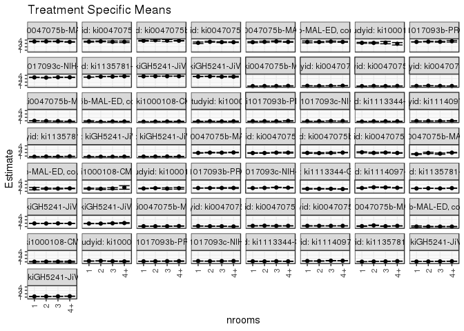

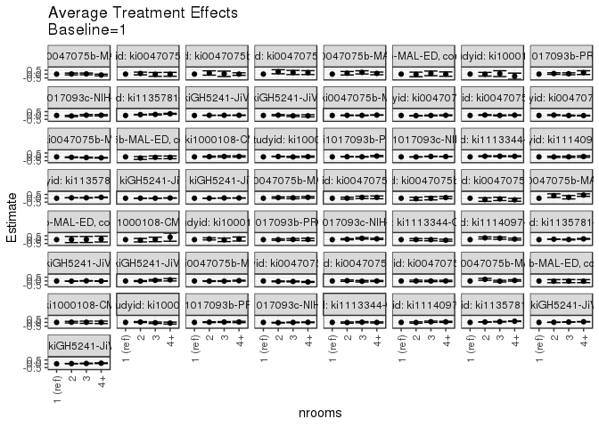

## Results Table

### Parameter: TSM

| agecat | studyid | country | intervention_level | baseline_level | estimate | ci_lower | ci_upper |
| --- | --- | --- | --- | --- | --- | --- | --- |
| 0-3 months | ki0047075b-MAL-ED | BANGLADESH | 1 | NA | 3.5685120 | 3.4925752 | 3.6444489 |
| 0-3 months | ki0047075b-MAL-ED | BANGLADESH | 2 | NA | 3.5836410 | 3.4824934 | 3.6847885 |
| 0-3 months | ki0047075b-MAL-ED | BANGLADESH | 3 | NA | 3.5936840 | 3.5000161 | 3.6873519 |
| 0-3 months | ki0047075b-MAL-ED | BANGLADESH | 4+ | NA | 3.4527824 | 3.3644946 | 3.5410701 |
| 0-3 months | ki0047075b-MAL-ED | INDIA | 1 | NA | 3.5229131 | 3.3941291 | 3.6516971 |
| 0-3 months | ki0047075b-MAL-ED | INDIA | 2 | NA | 3.6011804 | 3.4809035 | 3.7214573 |
| 0-3 months | ki0047075b-MAL-ED | INDIA | 3 | NA | 3.4893650 | 3.2759174 | 3.7028126 |
| 0-3 months | ki0047075b-MAL-ED | INDIA | 4+ | NA | 3.4981858 | 3.2832704 | 3.7131012 |
| 0-3 months | ki0047075b-MAL-ED | NEPAL | 1 | NA | 3.7962547 | 3.6627994 | 3.9297100 |
| 0-3 months | ki0047075b-MAL-ED | NEPAL | 2 | NA | 3.9384490 | 3.6928833 | 4.1840146 |
| 0-3 months | ki0047075b-MAL-ED | NEPAL | 3 | NA | 3.8360932 | 3.5185353 | 4.1536511 |
| 0-3 months | ki0047075b-MAL-ED | NEPAL | 4+ | NA | 3.7972276 | 3.6988385 | 3.8956167 |
| 0-3 months | ki0047075b-MAL-ED | PERU | 1 | NA | 3.1803412 | 2.9397364 | 3.4209460 |
| 0-3 months | ki0047075b-MAL-ED | PERU | 2 | NA | 3.4869166 | 3.3749009 | 3.5989324 |
| 0-3 months | ki0047075b-MAL-ED | PERU | 3 | NA | 3.3861092 | 3.2603411 | 3.5118772 |
| 0-3 months | ki0047075b-MAL-ED | PERU | 4+ | NA | 3.3716367 | 3.2929967 | 3.4502768 |
| 0-3 months | ki0047075b-MAL-ED | SOUTH AFRICA | 1 | NA | 3.3711198 | 3.2182056 | 3.5240340 |
| 0-3 months | ki0047075b-MAL-ED | SOUTH AFRICA | 2 | NA | 3.4825990 | 3.3066972 | 3.6585009 |
| 0-3 months | ki0047075b-MAL-ED | SOUTH AFRICA | 3 | NA | 3.5923622 | 3.4436784 | 3.7410460 |
| 0-3 months | ki0047075b-MAL-ED | SOUTH AFRICA | 4+ | NA | 3.4601719 | 3.3544064 | 3.5659375 |
| 0-3 months | ki0047075b-MAL-ED | TANZANIA, UNITED REPUBLIC OF | 1 | NA | 3.4607007 | 3.2036837 | 3.7177176 |
| 0-3 months | ki0047075b-MAL-ED | TANZANIA, UNITED REPUBLIC OF | 2 | NA | 3.4201400 | 3.2741965 | 3.5660835 |
| 0-3 months | ki0047075b-MAL-ED | TANZANIA, UNITED REPUBLIC OF | 3 | NA | 3.5515895 | 3.3897097 | 3.7134693 |
| 0-3 months | ki0047075b-MAL-ED | TANZANIA, UNITED REPUBLIC OF | 4+ | NA | 3.4633720 | 3.3452782 | 3.5814658 |
| 0-3 months | ki1000108-IRC | INDIA | 1 | NA | 3.1790069 | 3.0225959 | 3.3354179 |
| 0-3 months | ki1000108-IRC | INDIA | 2 | NA | 3.1597484 | 2.9781523 | 3.3413445 |
| 0-3 months | ki1000108-IRC | INDIA | 3 | NA | 3.2383679 | 2.8955604 | 3.5811754 |
| 0-3 months | ki1000108-IRC | INDIA | 4+ | NA | 2.9016292 | 2.5302918 | 3.2729667 |
| 0-3 months | ki1017093b-PROVIDE | BANGLADESH | 1 | NA | 3.4605693 | 3.4141942 | 3.5069443 |
| 0-3 months | ki1017093b-PROVIDE | BANGLADESH | 2 | NA | 3.5346031 | 3.4436352 | 3.6255710 |

[output cut: 198 more lines]

### Parameter: E(Y)

| agecat | studyid | country | intervention_level | baseline_level | estimate | ci_lower | ci_upper |
| --- | --- | --- | --- | --- | --- | --- | --- |
| 0-3 months | ki0047075b-MAL-ED | BANGLADESH | NA | NA | 3.5715787 | 3.5085237 | 3.6346338 |
| 0-3 months | ki0047075b-MAL-ED | INDIA | NA | NA | 3.5688019 | 3.4917177 | 3.6458861 |
| 0-3 months | ki0047075b-MAL-ED | NEPAL | NA | NA | 3.8178619 | 3.7415249 | 3.8941989 |
| 0-3 months | ki0047075b-MAL-ED | PERU | NA | NA | 3.3345392 | 3.2720665 | 3.3970119 |
| 0-3 months | ki0047075b-MAL-ED | SOUTH AFRICA | NA | NA | 3.4366827 | 3.3435842 | 3.5297813 |
| 0-3 months | ki0047075b-MAL-ED | TANZANIA, UNITED REPUBLIC OF | NA | NA | 3.4772891 | 3.3996638 | 3.5549143 |
| 0-3 months | ki1000108-IRC | INDIA | NA | NA | 3.1685972 | 3.0563410 | 3.2808533 |
| 0-3 months | ki1017093b-PROVIDE | BANGLADESH | NA | NA | 3.4826706 | 3.4434873 | 3.5218539 |
| 0-3 months | ki1017093c-NIH-Crypto | BANGLADESH | NA | NA | 3.3028656 | 3.2646714 | 3.3410598 |
| 0-3 months | ki1135781-COHORTS | INDIA | NA | NA | 3.5329262 | 3.5160350 | 3.5498174 |
| 0-3 months | kiGH5241-JiVitA-3 | BANGLADESH | NA | NA | 3.7183577 | 3.7080161 | 3.7286992 |
| 0-3 months | kiGH5241-JiVitA-4 | BANGLADESH | NA | NA | 3.6386177 | 3.6075243 | 3.6697112 |
| 3-6 months | ki0047075b-MAL-ED | BANGLADESH | NA | NA | 1.9280462 | 1.8787523 | 1.9773401 |
| 3-6 months | ki0047075b-MAL-ED | INDIA | NA | NA | 1.8837264 | 1.8224393 | 1.9450135 |
| 3-6 months | ki0047075b-MAL-ED | NEPAL | NA | NA | 1.9680995 | 1.9120346 | 2.0241643 |
| 3-6 months | ki0047075b-MAL-ED | PERU | NA | NA | 2.0183213 | 1.9525900 | 2.0840526 |
| 3-6 months | ki0047075b-MAL-ED | SOUTH AFRICA | NA | NA | 1.9877371 | 1.9066803 | 2.0687939 |
| 3-6 months | ki0047075b-MAL-ED | TANZANIA, UNITED REPUBLIC OF | NA | NA | 1.8300902 | 1.7622436 | 1.8979368 |
| 3-6 months | ki1000108-CMC-V-BCS-2002 | INDIA | NA | NA | 1.8037880 | 1.7029866 | 1.9045894 |
| 3-6 months | ki1000108-IRC | INDIA | NA | NA | 1.8759294 | 1.8124309 | 1.9394280 |
| 3-6 months | ki1017093b-PROVIDE | BANGLADESH | NA | NA | 1.9654454 | 1.9303798 | 2.0005110 |
| 3-6 months | ki1017093c-NIH-Crypto | BANGLADESH | NA | NA | 2.0057973 | 1.9693775 | 2.0422170 |
| 3-6 months | ki1113344-GMS-Nepal | NEPAL | NA | NA | 1.7057418 | 1.6666784 | 1.7448052 |
| 3-6 months | ki1114097-CONTENT | PERU | NA | NA | 2.0841841 | 2.0362519 | 2.1321163 |
| 3-6 months | ki1135781-COHORTS | INDIA | NA | NA | 1.8574178 | 1.8434023 | 1.8714334 |
| 3-6 months | kiGH5241-JiVitA-3 | BANGLADESH | NA | NA | 1.9202659 | 1.9098042 | 1.9307275 |
| 3-6 months | kiGH5241-JiVitA-4 | BANGLADESH | NA | NA | 1.8987567 | 1.8688242 | 1.9286892 |
| 6-12 months | ki0047075b-MAL-ED | BANGLADESH | NA | NA | 1.1143928 | 1.0896103 | 1.1391753 |
| 6-12 months | ki0047075b-MAL-ED | INDIA | NA | NA | 1.1210558 | 1.0926349 | 1.1494766 |
| 6-12 months | ki0047075b-MAL-ED | NEPAL | NA | NA | 1.2224454 | 1.1966480 | 1.2482429 |
| 6-12 months | ki0047075b-MAL-ED | PERU | NA | NA | 1.2102315 | 1.1775158 | 1.2429472 |
| 6-12 months | ki0047075b-MAL-ED | SOUTH AFRICA | NA | NA | 1.1895267 | 1.1483723 | 1.2306812 |
| 6-12 months | ki0047075b-MAL-ED | TANZANIA, UNITED REPUBLIC OF | NA | NA | 1.0019524 | 0.9648566 | 1.0390481 |
| 6-12 months | ki1000108-CMC-V-BCS-2002 | INDIA | NA | NA | 1.0624474 | 1.0146679 | 1.1102268 |
| 6-12 months | ki1000108-IRC | INDIA | NA | NA | 1.2493708 | 1.2200516 | 1.2786900 |
| 6-12 months | ki1017093b-PROVIDE | BANGLADESH | NA | NA | 1.1731762 | 1.1558671 | 1.1904853 |
| 6-12 months | ki1017093c-NIH-Crypto | BANGLADESH | NA | NA | 1.2281313 | 1.2106849 | 1.2455776 |
| 6-12 months | ki1113344-GMS-Nepal | NEPAL | NA | NA | 1.1681560 | 1.1485303 | 1.1877817 |
| 6-12 months | ki1114097-CONTENT | PERU | NA | NA | 1.3010517 | 1.2719491 | 1.3301542 |
| 6-12 months | ki1135781-COHORTS | INDIA | NA | NA | 1.0833099 | 1.0736358 | 1.0929841 |
| 6-12 months | kiGH5241-JiVitA-3 | BANGLADESH | NA | NA | 1.1068788 | 1.1001344 | 1.1136232 |
| 6-12 months | kiGH5241-JiVitA-4 | BANGLADESH | NA | NA | 1.2031561 | 1.1927695 | 1.2135427 |
| 12-24 months | ki0047075b-MAL-ED | BANGLADESH | NA | NA | 0.8459764 | 0.8299714 | 0.8619814 |
| 12-24 months | ki0047075b-MAL-ED | INDIA | NA | NA | 0.8803730 | 0.8630530 | 0.8976931 |
| 12-24 months | ki0047075b-MAL-ED | NEPAL | NA | NA | 0.8617083 | 0.8463512 | 0.8770654 |
| 12-24 months | ki0047075b-MAL-ED | PERU | NA | NA | 0.8463453 | 0.8256453 | 0.8670453 |
| 12-24 months | ki0047075b-MAL-ED | SOUTH AFRICA | NA | NA | 0.8699064 | 0.8475321 | 0.8922808 |
| 12-24 months | ki0047075b-MAL-ED | TANZANIA, UNITED REPUBLIC OF | NA | NA | 0.7663111 | 0.7428636 | 0.7897586 |
| 12-24 months | ki1000108-CMC-V-BCS-2002 | INDIA | NA | NA | 0.7397013 | 0.7128622 | 0.7665404 |
| 12-24 months | ki1000108-IRC | INDIA | NA | NA | 0.8304303 | 0.8110434 | 0.8498173 |
| 12-24 months | ki1017093b-PROVIDE | BANGLADESH | NA | NA | 0.8575519 | 0.8455586 | 0.8695452 |
| 12-24 months | ki1017093c-NIH-Crypto | BANGLADESH | NA | NA | 0.8755729 | 0.8637860 | 0.8873598 |
| 12-24 months | ki1113344-GMS-Nepal | NEPAL | NA | NA | 0.8378848 | 0.8224521 | 0.8533174 |
| 12-24 months | ki1114097-CONTENT | PERU | NA | NA | 0.9259464 | 0.8927736 | 0.9591191 |
| 12-24 months | ki1135781-COHORTS | INDIA | NA | NA | 0.8192215 | 0.8133282 | 0.8251148 |
| 12-24 months | kiGH5241-JiVitA-3 | BANGLADESH | NA | NA | 0.7965288 | 0.7912208 | 0.8018367 |
| 12-24 months | kiGH5241-JiVitA-4 | BANGLADESH | NA | NA | 0.8492623 | 0.8438054 | 0.8547191 |

### Parameter: ATE

| agecat | studyid | country | intervention_level | baseline_level | estimate | ci_lower | ci_upper |
| --- | --- | --- | --- | --- | --- | --- | --- |
| 0-3 months | ki0047075b-MAL-ED | BANGLADESH | 1 | 1 | 0.0000000 | 0.0000000 | 0.0000000 |
| 0-3 months | ki0047075b-MAL-ED | BANGLADESH | 2 | 1 | 0.0151289 | -0.1032701 | 0.1335279 |
| 0-3 months | ki0047075b-MAL-ED | BANGLADESH | 3 | 1 | 0.0251719 | -0.0847302 | 0.1350741 |
| 0-3 months | ki0047075b-MAL-ED | BANGLADESH | 4+ | 1 | -0.1157297 | -0.2248056 | -0.0066537 |
| 0-3 months | ki0047075b-MAL-ED | INDIA | 1 | 1 | 0.0000000 | 0.0000000 | 0.0000000 |
| 0-3 months | ki0047075b-MAL-ED | INDIA | 2 | 1 | 0.0782673 | -0.0979691 | 0.2545038 |
| 0-3 months | ki0047075b-MAL-ED | INDIA | 3 | 1 | -0.0335481 | -0.2827697 | 0.2156735 |
| 0-3 months | ki0047075b-MAL-ED | INDIA | 4+ | 1 | -0.0247273 | -0.2753263 | 0.2258717 |
| 0-3 months | ki0047075b-MAL-ED | NEPAL | 1 | 1 | 0.0000000 | 0.0000000 | 0.0000000 |
| 0-3 months | ki0047075b-MAL-ED | NEPAL | 2 | 1 | 0.1421943 | -0.1372924 | 0.4216809 |
| 0-3 months | ki0047075b-MAL-ED | NEPAL | 3 | 1 | 0.0398386 | -0.3046224 | 0.3842995 |
| 0-3 months | ki0047075b-MAL-ED | NEPAL | 4+ | 1 | 0.0009730 | -0.1648303 | 0.1667762 |
| 0-3 months | ki0047075b-MAL-ED | PERU | 1 | 1 | 0.0000000 | 0.0000000 | 0.0000000 |
| 0-3 months | ki0047075b-MAL-ED | PERU | 2 | 1 | 0.3065755 | 0.0422558 | 0.5708951 |
| 0-3 months | ki0047075b-MAL-ED | PERU | 3 | 1 | 0.2057680 | -0.0652852 | 0.4768212 |
| 0-3 months | ki0047075b-MAL-ED | PERU | 4+ | 1 | 0.1912956 | -0.0616229 | 0.4442140 |
| 0-3 months | ki0047075b-MAL-ED | SOUTH AFRICA | 1 | 1 | 0.0000000 | 0.0000000 | 0.0000000 |
| 0-3 months | ki0047075b-MAL-ED | SOUTH AFRICA | 2 | 1 | 0.1114793 | -0.1174137 | 0.3403723 |
| 0-3 months | ki0047075b-MAL-ED | SOUTH AFRICA | 3 | 1 | 0.2212424 | 0.0143857 | 0.4280991 |
| 0-3 months | ki0047075b-MAL-ED | SOUTH AFRICA | 4+ | 1 | 0.0890521 | -0.0873969 | 0.2655011 |
| 0-3 months | ki0047075b-MAL-ED | TANZANIA, UNITED REPUBLIC OF | 1 | 1 | 0.0000000 | 0.0000000 | 0.0000000 |
| 0-3 months | ki0047075b-MAL-ED | TANZANIA, UNITED REPUBLIC OF | 2 | 1 | -0.0405607 | -0.3360559 | 0.2549346 |
| 0-3 months | ki0047075b-MAL-ED | TANZANIA, UNITED REPUBLIC OF | 3 | 1 | 0.0908888 | -0.2128517 | 0.3946294 |
| 0-3 months | ki0047075b-MAL-ED | TANZANIA, UNITED REPUBLIC OF | 4+ | 1 | 0.0026713 | -0.2801553 | 0.2854979 |
| 0-3 months | ki1000108-IRC | INDIA | 1 | 1 | 0.0000000 | 0.0000000 | 0.0000000 |
| 0-3 months | ki1000108-IRC | INDIA | 2 | 1 | -0.0192585 | -0.2587103 | 0.2201932 |
| 0-3 months | ki1000108-IRC | INDIA | 3 | 1 | 0.0593610 | -0.3161372 | 0.4348592 |
| 0-3 months | ki1000108-IRC | INDIA | 4+ | 1 | -0.2773776 | -0.6799468 | 0.1251915 |
| 0-3 months | ki1017093b-PROVIDE | BANGLADESH | 1 | 1 | 0.0000000 | 0.0000000 | 0.0000000 |
| 0-3 months | ki1017093b-PROVIDE | BANGLADESH | 2 | 1 | 0.0740339 | -0.0275840 | 0.1756517 |

[output cut: 198 more lines]